# Coursework Report

*N* removed NAs: 3

*N* removed typo: 1

*N* removed <18: 25

*N* total clean: 121

| Group | *N* | *M*<sub>age</sub> | *M*<sub>rating</sub> |
| --- | --- | --- | --- |
| Control | 57 | 20.68 | 6.62 |
| Experim | 64 | 21.11 | 5.53 |

**Main analysis results**

*t*(119) = 8.21, *p* < .001

[interactive chart not shown]

[figure not shown]

[interactive chart not shown]

# Coursework Report

Analysing Data, Spring 2020

# Methods

## Participants

*Table 1* Summary of Participant Demongraphics by Experimental Condition

| Condition | Count | *M*<sub>age</sub> | *SD*<sub>age</sub> |
| --- | --- | --- | --- |
| White | 57 | 20.68 | 1.77 |
| Red | 64 | 21.11 | 1.82 |

## Design

The study examines the effects of the colours red and white on perceived attractiveness. It used an independent measures design. Participants were randomly allocated into one of two experimental conditions.In the experimental condition, the participant saw a black and white image of a target man on a red background (n = 64). On the other hand, in the control condition, the image shown had a white background (n = 57). The colour white was used as it is considered the absence of a background colour. After viewing the image the participants were asked to rate the attractiveness of the man in the image. They were asked three factors; “How attractive do you think this person is?”, “How pleasant is this person to look at?” and “If I were to meet the person in this picture face to face, I would think he is attractive.”. These items were rated on a 9-point scale (1 = “Not at all attractive” to 9 = “extremely attractive”). It is hypothesised that those in the red condition will have a higher rating of perceived attractiveness than those in the white condition.The ratings will be averaged to create a composite score and then the results will undergo an independent measures *t*-test.

# Results

## Descriptive Statistics

*Table 2* demonstrates a summary of participants responses to the 3 questions. The mean is higher in the control condition across all the three questions and the standard deviation remains similar across all the questions indicating the results were all somewhat close to the mean.

*Table 2* Summary of Mean Ratings by Experimental Condition

| Condition | Question 1 *M* | Question 1 *SD* | Question 2 *M* | Question 2 *SD* | Question 3 *M* | Question 3 *SD* |
| --- | --- | --- | --- | --- | --- | --- |
| White | 6.28 | 1.22 | 6.53 | 1.18 | 7.05 | 1.17 |
| Red | 5.44 | 1.17 | 5.34 | 1.28 | 5.81 | 1.44 |

A composite score was calculated by finding the mean rating for the three questions. This score was used to create *Graph 1*. The graph demonstrates that there is an apparent higher mean attractiveness rating for the control condition.

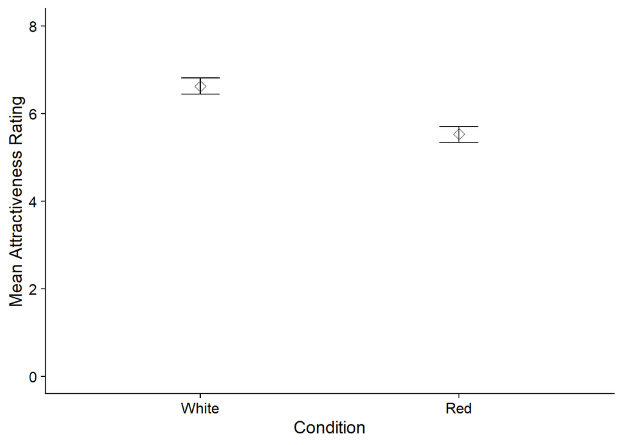

## Inferential Statistics

It was investigated whether, as predicted, people would rate the male as more attractive in the red background condition using an independent measures *t*-test. The test demonstrated that the means in the two conditions (white and red) differed by 1.09 (*M*<sub>diff</sub> = 1.09, 95% CI [0.83, 1.35]). This indicates that there was a significant difference between the two groups on the composite score of ratings of attractiveness (*t* (119) = 8.21, *p* = < .001). This means we can reject the null hypothesis that colour has no effect on attractiveness ratings. The difference is significant, however, it is not inline with the hypothesis that those in the red condition would rate the male as more attractive because the mean attractiveness ratings were significantly lower in the experimental condition.

# Discussion

There are a few potential limitations to this study which may help to explain the contradicting results. First, using a black and white image of a man over a red background potentially reduces the ecological validity. In that, the background would stand out more to the participant which could have an effect on how they respond to the image. Potentially the picture could be taken against a red wall or the man colour wear red rather than editing the image over a red background to increase ecological validity. In addition, this study design fails to address individual differences in what is attractive. Nevertheless, this limitation would be extremely difficult to control without increasing demand characteristics as participants cannot participate in both conditions.

A potential explanation behind why the results found in the study were contradictory could be that, along with romance, red is also connoted with anger and aggression, thus this may explain the lower attractiveness ratings (Wright & Rainwater, 1962). This means that potentially other colours with less conflicting connotations could be investigated. For example, pink also has connotations with romance and charm and has less negative connotations (Wright & Rainwater, 1962). Thus, research into other colours on perceived attractiveness is required to have a rounder picture of the effects of colour on attractiveness. The findings in this study do not support the suggestion that red increases perceived attractiveness. However, due to much conflicting research, further testing taking into account the limitations is required to conclusively say whether colour has an effect on perceived attractiveness or not.

# References

Elliot, A. J., Niesta Kayser, D.,Greitemeyer, T., Lictenfield, S., Gramzow, R. H., Maier, M. A., & Liu, H. (2010). Red, rank, and romance in women viewing men. *Journal of Experimental Psychology: General, 139*(3), 399.

Hesslinger, V., Goldbach, L., & Carbon, C. (2015). Men in red: A reexamination of the red-attractiveness effect. *Psychonomic Bulletin & Review, 22(4), 1142-1148. doi: 10.3758/s13423-015-0866-8*

Peperkoorn, L., Roberts, S., & Pollet, T. (2016). Revisiting the Red Effect on Attractiveness and Sexual Receptivity. *Evolutionary Psychology, 14*(4), 147470491667384. doi: 10.1177/1474704916673841

Wright B. & Rainwater L. (1962). The Meanings of Color. *The Journal of General Psychology, 67*(1), 89-99, DOI: 10.1080/00221309.1962.9711531